# CS2-15: Loss Distributions

### Normal Distribution

```r
dnorm(1, mean = 3, sd = 2)
```

```
## [1] 0.1209854
```

```r
pnorm(3, mean = 3, sd = 2)
```

```
## [1] 0.5
```

```r
qnorm(0.25, mean = 3, sd = 2)
```

```
## [1] 1.65102
```

```r
rnorm(10, mean = 3, sd = 2)
```

```
##  [1] 5.5861528 5.0070988 0.6574905 2.1097083 4.3532580 2.7611928 3.4052633
##  [8] 2.7287767 4.1153127 3.5248915
```

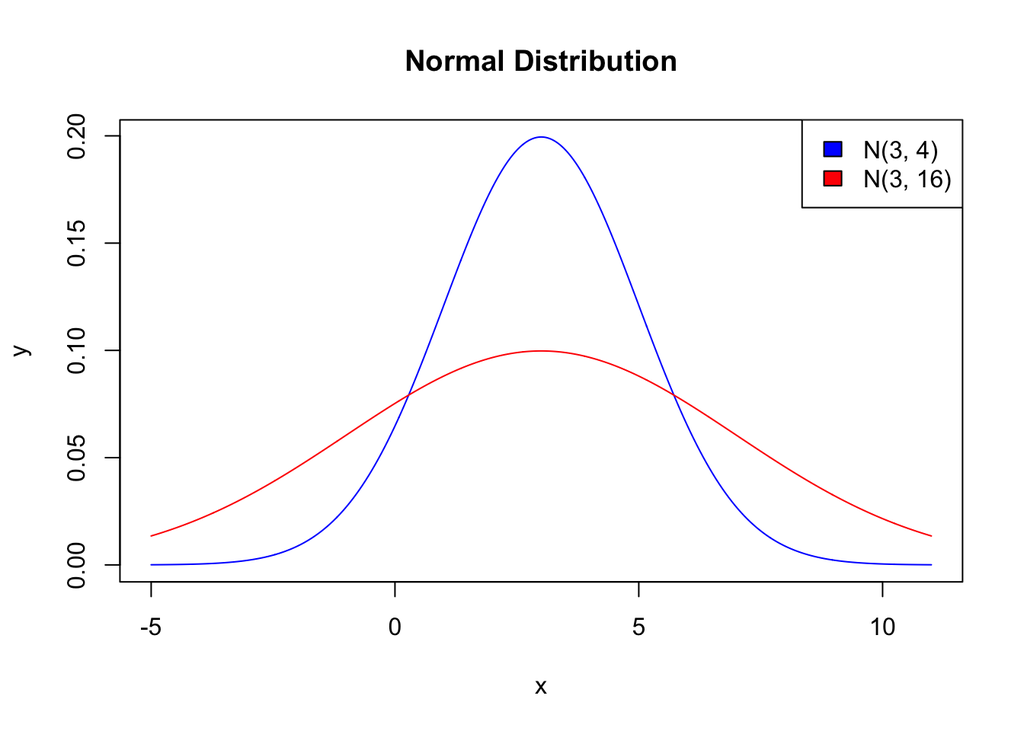

```r
plot(seq(-5, 11, 0.01), dnorm(seq(-5, 11, 0.01), mean = 3, sd = 2), type = "l", col = "blue", xlab = "x", ylab = "y", main = "Normal Distribution")
lines(seq(-5, 11, 0.01), dnorm(seq(-5, 11, 0.01), mean = 3, sd = 4), type = "l", col = "red")
legend("topright", c("N(3, 4)", "N(3, 16)"), fill = c("blue","red"))
```

### Lognormal Distribution

```r
dlnorm(1, meanlog = 3, sdlog = 2)
```

```
## [1] 0.0647588
```

```r
plnorm(3, meanlog = 3, sdlog = 2)
```

```
## [1] 0.1708799
```

```r
qlnorm(0.25, meanlog = 3, sdlog = 2)
```

```
## [1] 5.212296
```

```r
rlnorm(10, meanlog = 3, sdlog = 2)
```

```
##  [1] 2013.429039    1.219304  270.418626   65.076807    5.704166   78.127553
##  [7]    3.760430  185.335937   18.659319    1.287800
```

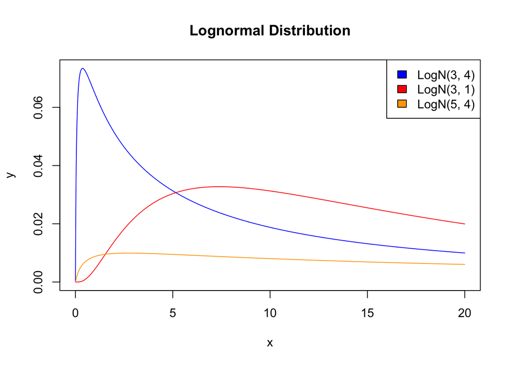

```r
plot(seq(0, 20, 0.01), dlnorm(seq(0, 20, 0.01), meanlog = 3, sdlog = 2), type = "l", col = "blue", xlab = "x", ylab = "y", main = "Lognormal Distribution")
lines(seq(0, 20, 0.01), dlnorm(seq(0, 20, 0.01), meanlog = 3, sdlog = 1), type = "l", col = "red")
lines(seq(0, 20, 0.01), dlnorm(seq(0, 20, 0.01), meanlog = 5, sdlog = 2), type = "l", col = "orange")
legend("topright", c("LogN(3, 4)", "LogN(3, 1)", "LogN(5, 4)"), fill = c("blue","red", "orange"))
```

### Pareto Distribution

There are no built-in functions for Pareto distribution, so here we are going to define them.

```r
dpareto <- function(x, a, l) {
  a*l^a / ((l+x) ^ (a+1))
}

ppareto <- function(x, a, l) {
  1 - (l / (l+x)) ^ a
}

qpareto <- function(q, a, l) {
  ((1-q) ^ (-1/a) - 1) * l
}

rpareto <- function(n, a, l) {
  ((1-runif(n)) ^ (-1/a) - 1) * l
}
```

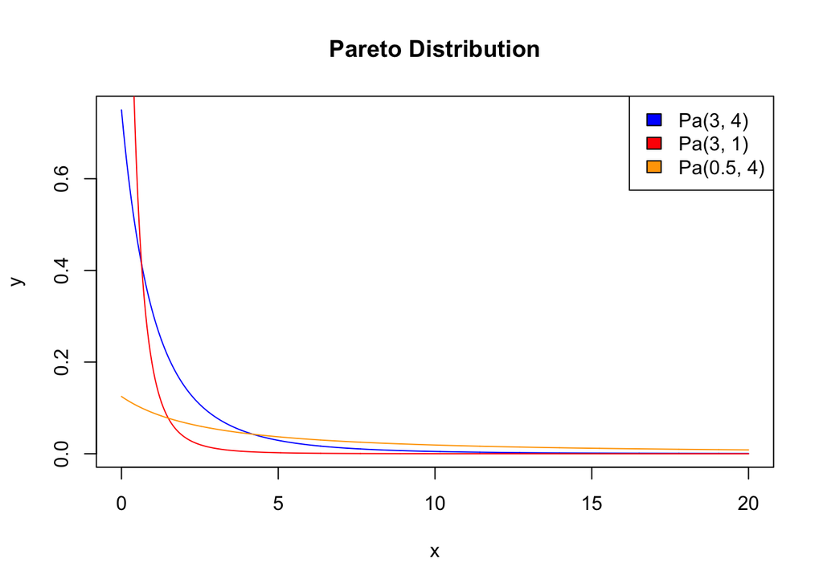

```r
plot(seq(0, 20, 0.01), dpareto(seq(0, 20, 0.01), 3, 4), type = "l", col = "blue", xlab = "x", ylab = "y", main = "Pareto Distribution")
lines(seq(0, 20, 0.01), dpareto(seq(0, 20, 0.01), 3, 1), type = "l", col = "red")
lines(seq(0, 20, 0.01), dpareto(seq(0, 20, 0.01), 0.5, 4), type = "l", col = "orange")
legend("topright", c("Pa(3, 4)", "Pa(3, 1)", "Pa(0.5, 4)"), fill = c("blue","red", "orange"))
```

Pareto distribution is always positively skewed, since its mean is always greater than its median.

```r
pareto_median <- qpareto(0.5, 3, 4)

integrand <- function(x) {x * 3*4^3 / (4+x)^(3+1)}
pareto_mean <- integrate(integrand, lower = 0, upper = Inf)[1]
# Alternatively, pareto_mean <- 4 / (3-1)

pareto_median < pareto_mean
```

```
## value
##  TRUE
```

### Burr Distribution

There are no built-in functions for Burr distribution, so here we are going to define them.

```r
dburr <- function(x, a, l, g) {
  a * g * (l^a) * (x^(g-1)) / ((l+x^g) ^ (a+1))
}

pburr <- function(x, a, l, g) {
  1 - (l / (l+x^g)) ^ a
}

qburr <- function(q, a, l, g) {
  (((1-q)^(-1/a) - 1) * l) ^ (1/g)
}

rburr <- function(n, a, l, g) {
  (((1-runif(n))^(-1/a) - 1) * l) ^ (1/g)
}
```

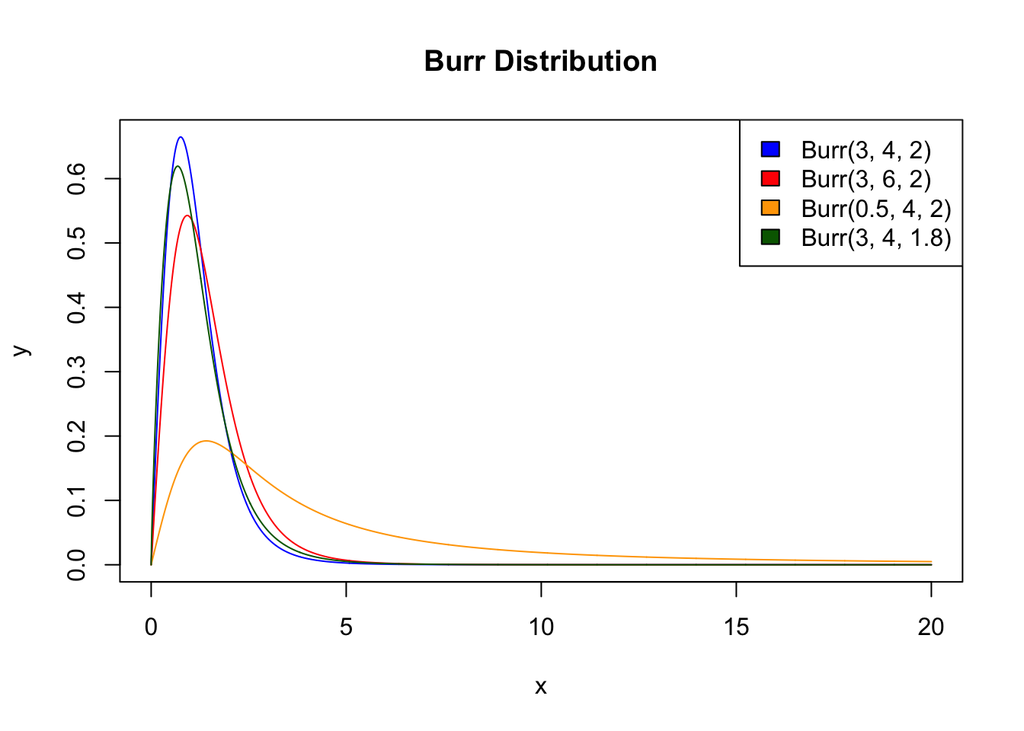

```r
plot(seq(0, 20, 0.01), dburr(seq(0, 20, 0.01), 3, 4, 2), type = "l", col = "blue", xlab = "x", ylab = "y", main = "Burr Distribution")
lines(seq(0, 20, 0.01), dburr(seq(0, 20, 0.01), 3, 6, 2), type = "l", col = "red")
lines(seq(0, 20, 0.01), dburr(seq(0, 20, 0.01), 0.5, 4, 2), type = "l", col = "orange")
lines(seq(0, 20, 0.01), dburr(seq(0, 20, 0.01), 3, 4, 1.8), type = "l", col = "darkgreen")
legend("topright", c("Burr(3, 4, 2)", "Burr(3, 6, 2)", "Burr(0.5, 4, 2)", "Burr(3, 4, 1.8)"), fill = c("blue","red", "orange", "darkgreen"))
```

### Weibull Distribution

In `R` built-in functions, the parameterization is slightly different. The Weibull distribution with `shape` parameter $a$ and `scale` parameter $\sigma$ has density given by $f(x) = (a/\sigma) {(x/\sigma)}^{a-1} e^{-{(x/\sigma)}^{a}}$. In CS2 context, we reparameterize it into $\text{Weibull}(c, \gamma)$, which has density given by $f(x) = c \gamma x^{\gamma-1} e^{-cx^{\gamma}}$, then the `shape` parameter should be $\gamma$, and the `scale` parameter should be $c^{-1/\gamma}$.

```r
# Weibull(2, 0.25)
dweibull(1, shape = 0.25, scale = 2^(-1/0.25))
```

```
## [1] 0.06766764
```

```r
pweibull(1, shape = 0.25, scale = 2^(-1/0.25))
```

```
## [1] 0.8646647
```

```r
qweibull(0.25, shape = 0.25, scale = 2^(-1/0.25))
```

```
## [1] 0.0004280862
```

```r
rweibull(10, shape = 0.25, scale = 2^(-1/0.25))
```

```
##  [1] 0.0218599593 4.8079081775 0.0002673788 0.0028587743 0.0814015147
##  [6] 0.5618975209 0.1769310368 0.0001090972 0.1932555028 0.0003815697
```

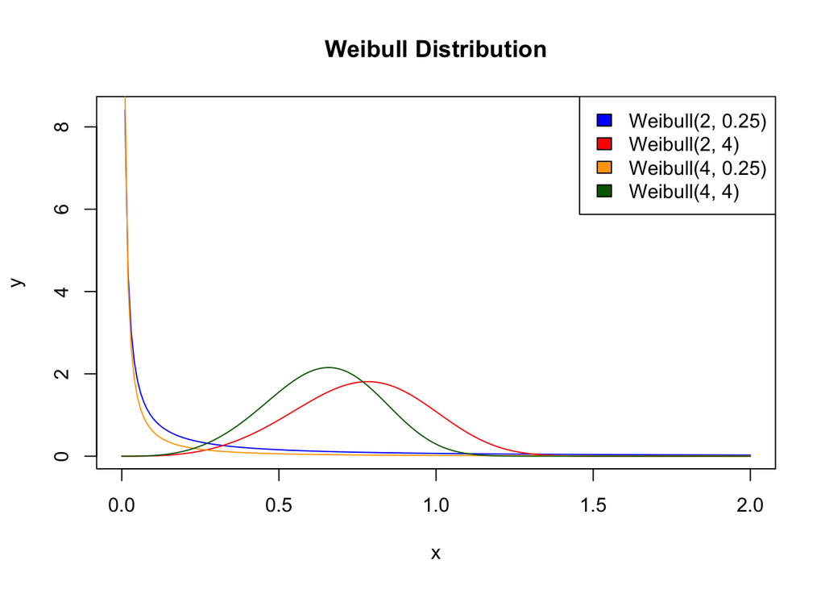

```r
plot(seq(0, 2, 0.01), dweibull(seq(0, 2, 0.01), shape = 0.25, scale = 2^(-1/0.25)), type = "l", col = "blue", xlab = "x", ylab = "y", main = "Weibull Distribution")
lines(seq(0, 2, 0.01), dweibull(seq(0, 2, 0.01), shape = 4, scale = 2^(-1/4)), type = "l", col = "red")
lines(seq(0, 2, 0.01), dweibull(seq(0, 2, 0.01), shape = 0.25, scale = 4^(-1/0.25)), type = "l", col = "orange")
lines(seq(0, 2, 0.01), dweibull(seq(0, 2, 0.01), shape = 4, scale = 4^(-1/4)), type = "l", col = "darkgreen")
legend("topright", c("Weibull(2, 0.25)", "Weibull(2, 4)", "Weibull(4, 0.25)", "Weibull(4, 4)"), fill = c("blue","red", "orange", "darkgreen"))
```

Alternatively, we can redefine them:

```r
dweibull_def <- function(x, c, g) {
  c * g * x^(g-1) * exp(-c*x^g)
}

pweibull_def <- function(x, c, g) {
  1 - exp(-c*x^g)
}

qweibull_def <- function(q, c, g) {
  (log(1-q) / (-c)) ^ (1/g)
}

rweibull_def <- function(n, c, g) {
  (log(1-runif(n)) / (-c)) ^ (1/g)
}
```

Check if the built-in Weibull functions and user-defined Weibull functions have the same output:

```r
qweibull(0.25, shape = 0.25, scale = 2^(-1/0.25))
```

```
## [1] 0.0004280862
```

```r
qweibull_def(0.25, c = 2, g = 0.25)
```

```
## [1] 0.0004280862
```

### Illustration of Tail Weights

All distributions below have a mean of 1000.

A: Weibull($\frac{\pi}{2000^2}$, 2)

B: Exp($\frac{1}{1000}$)

C: Pareto(3, 2000)

D: Weibull($\frac{1}{\sqrt{500}}$, $\frac{1}{2}$)

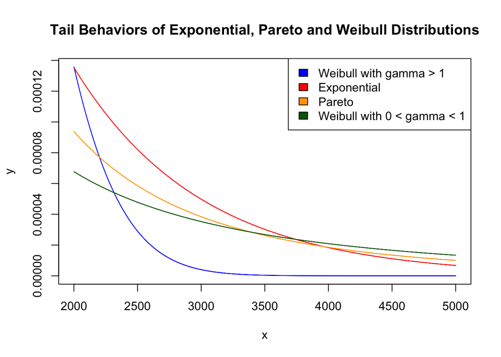

```r
plot(seq(2000, 5000, 0.01), dweibull(seq(2000, 5000, 0.01), shape = 2, scale = (pi/2000^2)^(-1/2)), type = "l", col = "blue", xlab = "x", ylab = "y", main = "Tail Behaviors of Exponential, Pareto and Weibull Distributions")
lines(seq(2000, 5000, 0.01), dexp(seq(2000, 5000, 0.01), rate = 1/1000), type = "l", col = "red")
lines(seq(2000, 5000, 0.01), dpareto(seq(2000, 5000, 0.01), 3, 2000), type = "l", col = "orange")
lines(seq(2000, 5000, 0.01), dweibull(seq(2000, 5000, 0.01), shape = 1/2, scale = (1/sqrt(500))^(-2)), type = "l", col = "darkgreen")
legend("topright", c("Weibull with gamma > 1", "Exponential", "Pareto", "Weibull with 0 < gamma < 1"), fill = c("blue", "red", "orange", "darkgreen"))
```